# **Week 3 Project**

## Yunjae Choi

Compiled on Tue Mar 14 22:50:07 2017.

#### The Basics

- What mode of graphic is it? (e.g. density plot, scatter plot, bar plot, …)

  ```
  density plot
  ```

- What variables from the respective data tables are involved?

  ```
  bmi, sex, pregnancy (yes/ no)
  ```

- What role each of those variables plays in the graphic?

  ```
  pregnancy - divided into two layers
  sex - using color codes (aesthetics)
  density plot of bmi depending on sex and preg
  ```

#### Making Plots

```r
library(mosaicData)
library(ggplot2)
```

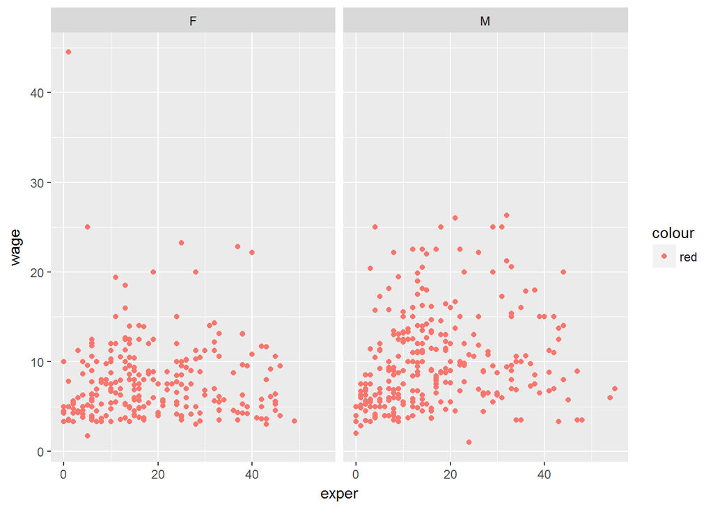

```r
ggplot(data = CPS85, aes(x = exper, y = wage, color = "red")) + geom_point() + facet_wrap( ~ sex)
```

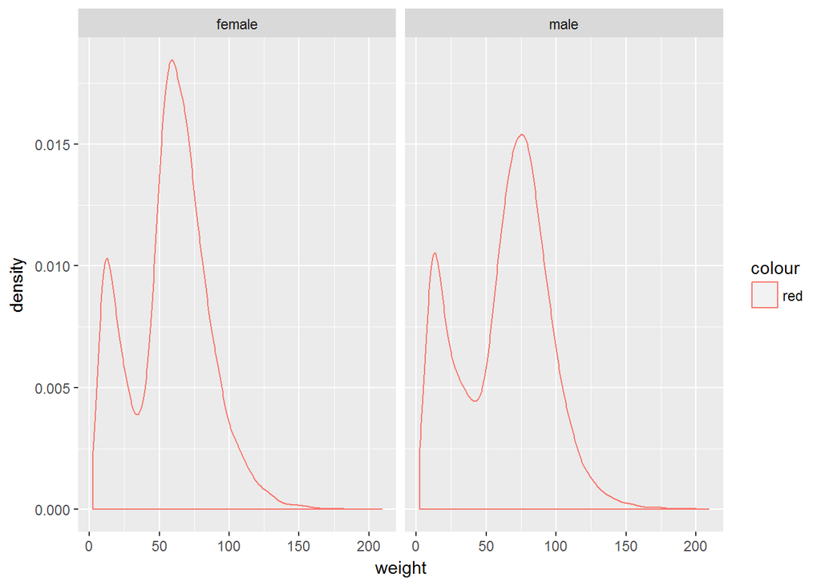

```r
ggplot(data = NCHS, aes(x = weight)) + geom_density(aes(color = "red")) + facet_wrap(~ sex)
```

#### Diamonds

1. Which color diamonds seem to be largest on average (in terms of carats)?  
   J is the largest on average

```r
diamonds %>%
  group_by( color ) %>%
  summarise(carat_size = mean(carat)) %>%
  arrange(desc(carat_size)) %>%
  head( 10 )
```

```
## # A tibble: 7 × 2
##   color carat_size
##   <ord>      <dbl>
## 1     J  1.1621368
## 2     I  1.0269273
## 3     H  0.9117991
## 4     G  0.7711902
## 5     F  0.7365385
## 6     E  0.6578667
## 7     D  0.6577948
```

2. Which clarity of diamonds has the largest average “table” per carat?

```r
diamonds %>%
  group_by( clarity ) %>%
  summarise(nmean = mean(table)) %>%
  arrange(desc(nmean)) %>%
  head( 10 )
```

```
## # A tibble: 8 × 2
##   clarity    nmean
##     <ord>    <dbl>
## 1      I1 58.30378
## 2     SI2 57.92718
## 3     SI1 57.66254
## 4     VS2 57.41740
## 5     VS1 57.31515
## 6    VVS2 57.02499
## 7    VVS1 56.88446
## 8      IF 56.50721
```

#### Voting

How many cases are there?

```r
Minneapolis2013 %>%
  summarise(nsum = n())
```

```
##    nsum
## 1 80101
```

Who were the top 5 candidates in the Second vote selections?

```r
Minneapolis2013 %>%
  group_by(Second) %>%
  summarise(nsum = n()) %>%
  arrange(desc(nsum)) %>%
  head( 5 )
```

```
## # A tibble: 5 × 2
##               Second  nsum
##                <chr> <int>
## 1       BETSY HODGES 14399
## 2        DON SAMUELS 14170
## 3        MARK ANDREW 12757
## 4          undervote 10598
## 5 JACKIE CHERRYHOMES  6470
```

How many ballots are marked “undervote” in First choice selections?

```r
Minneapolis2013 %>%
  filter(First == "undervote") %>%
  summarise(nsum = n())
```

```
##   nsum
## 1  834
```

Second choice selections?

```r
Minneapolis2013 %>%
  filter(Second == "undervote") %>%
  summarise(nsum = n())
```

```
##    nsum
## 1 10598
```

Third choice selections?

```r
Minneapolis2013 %>%
  filter(Third == "undervote") %>%
  summarise(nsum = n())
```

```
##    nsum
## 1 19210
```

What are the top 3 Second vote selections among people who voted for Betsy Hodges as their first choice?

```r
Minneapolis2013 %>%
  filter(First == "BETSY HODGES") %>%
  group_by(Second) %>%
  summarise(nsum = n()) %>%
  arrange(desc(nsum)) %>%
  head(3)
```

```
## # A tibble: 3 × 2
##               Second  nsum
##                <chr> <int>
## 1        MARK ANDREW  8787
## 2        DON SAMUELS  8743
## 3 JACKIE CHERRYHOMES  2563
```

Which Precinct had the highest fraction of First vote selections marked as “undervote”? (To calculate the fraction, use mean(First == “undervote”) in the argument to summarise().)

```r
Minneapolis2013 %>%
  group_by(Precinct) %>%
  summarise(frac = mean(First == "undervote")) %>%
  arrange(desc(frac)) %>%
  head(1)
```

```
## # A tibble: 1 × 2
##   Precinct       frac
##      <chr>      <dbl>
## 1     P-6C 0.07738095
```